# Why Machine Learning

Use case machine learning with R

Cevi Herdian, B. Sc

30.01.2019

**Note:**

-An R Notebook is an R Markdown document with chunks that can be executed independently and interactively, with output visible immediately beneath the input.

-Notebook output are available as HTML, PDF, Word, or Latex.

-This Notebook as HTML is preferably open with Google Chrome.

-R-Code can be extracted as Rmd file under the button “Code” in the notebook.

-This Notebook using iterative development. It means the process starts with a simple implementation of a small set of idea requirements and iteratively enhances the evolving versions until the complete version is implemented and perfect.

# Why Machine Learning

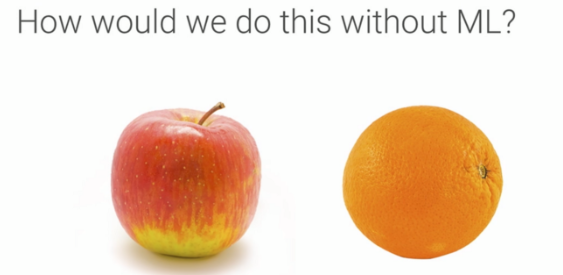

The properties are:

1. Color: “Red”-“Orange”
2. Shape: “Not completely circle”-“circle”
3. “Stalk is present”-“Stalk is not present”

and much more properties right??(if you have more properties list them in your mind or on paper for now)

what if the image is black and white like this? the color property listed is useless now

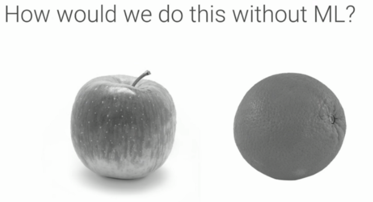

So it is impossible to list out all the properties in all the possible dimensions of each and everything that needs to be identified.

That’s why we need machine learning.

# Change log update

- 01.02.2019

# License

MIT